# Mert Erdinc BADS Final Assignment

### Ensemble Learning Models

#### Random Forest

```python
from sklearn.ensemble import RandomForestClassifier  #benchmark model just to see how the performance will turnout without
rf = RandomForestClassifier()                        #any hypertuning
rf.fit(X_train, y_train.values.ravel())
```

```python
yhat = rf.predict_proba(X_train)[:, 1]  #we overfit the data
print(roc_auc_score(y_train.sort_index(), yhat))
```

```
0.9998756181946155
```

```python
yhat = rf.predict_proba(X_test)[:, 1]
print(roc_auc_score(y_test.sort_index(), yhat))
```

```
0.6206409992502788
```

```python
from sklearn.model_selection import GridSearchCV #Using grid search method combined with cross validation
print('Tuning random forest classifier')
rf = RandomForestClassifier(random_state=888, max_samples = 0.5)  # This way, bootstrap sample size will be 50% of the training set

# Define meta-parameter grid of candidate settings
# The following settings are just for illustration
param_grid = {'n_estimators': [100, 200, 500, 1000],
              'max_features': [1, 2, 4, 7, 10, 13]
              }

# Set up the grid object specifying the tuning options
gs_rf = GridSearchCV(rf, param_grid, cv=5, scoring='roc_auc', verbose=1)
fit=gs_rf.fit(X_train, y_train.values.ravel())
gs_rf.fit(X_train, y_train.values.ravel())
```

```
Tuning random forest classifier
Fitting 5 folds for each of 24 candidates, totalling 120 fits
```

```
[Parallel(n_jobs=1)]: Using backend SequentialBackend with 1 concurrent workers.
[Parallel(n_jobs=1)]: Done 120 out of 120 | elapsed: 67.8min finished
```

```
GridSearchCV(cv=5,
             estimator=RandomForestClassifier(max_samples=0.5,
                                              random_state=888),
             param_grid={'max_features': [1, 2, 4, 7, 10, 13],
                         'n_estimators': [100, 200, 500, 1000]},
             scoring='roc_auc', verbose=1)
```

```python
print("Best CV AUC: %0.4f" % gs_rf.best_score_)
print("Optimal RF meta-parameters:")
print(gs_rf.best_params_)

from sklearn import metrics

auc_trace = {}

# Find test set auc of the best random forest classifier
fp_rate, tp_rate, _ = metrics.roc_curve(y_test, gs_rf.predict_proba(X_test)[:, 1])
auc_trace.update( {'rf' : metrics.auc(fp_rate, tp_rate)})
print('RF test set AUC: {:.4f}'.format(auc_trace['rf'])) #best result so far Optimal RF meta-parameters:
                                                         #{'max_features': 1, 'n_estimators': 500}
```

```
Best CV AUC: 0.5581
Optimal RF meta-parameters:
{'max_features': 1, 'n_estimators': 500}
RF test set AUC: 0.6334
```

```python
yhat_try_train = gs_rf.predict_proba(X_train)[:, 1]
print(roc_auc_score(y_train.sort_index(), yhat_try_train))
```

```
0.9995402015087554
```

```python
yhat_try_test = gs_rf.predict_proba(X_test)[:, 1]
print(roc_auc_score(y_test.sort_index(), yhat_try_test))
```

```
0.6334290852594004
```

```python
yhat_try_test
```

```
array([0.549     , 0.584     , 0.61      , ..., 0.617     , 0.472     ,
       0.50666667])
```

```python
rf = RandomForestClassifier(random_state=888, max_samples = 0.5, max_features = 1, n_estimators = 500)

fit=rf.fit(X_train, y_train.values.ravel())
fit
```

```
RandomForestClassifier(max_features=1, max_samples=0.5, n_estimators=500,
                       random_state=888)
```

```python
yhat1 = rf.predict_proba(X_train)[:, 1]
print(roc_auc_score(y_train.sort_index(), yhat1))
```

```
0.9995402015087554
```

```python
yhat2 = rf.predict_proba(X_test)[:, 1]
print(roc_auc_score(y_test.sort_index(), yhat2))
```

```
0.6334290852594004
```

```python
yhat
```

[output not shown]

```python
yhat2 #to make sure that they are the same
```

```
array([0.549     , 0.584     , 0.61      , ..., 0.617     , 0.472     ,
       0.50666667])
```

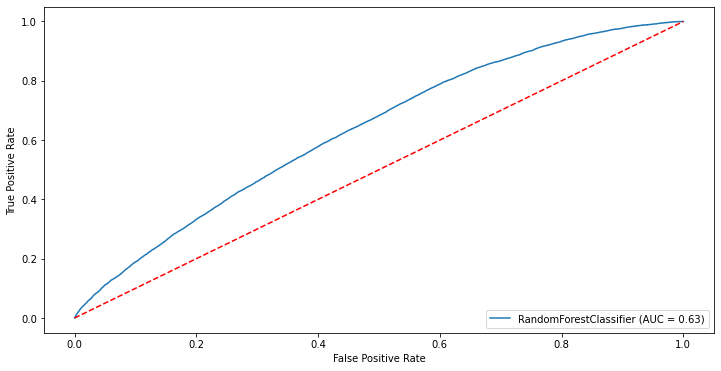

```python
metrics.plot_roc_curve(gs_rf.best_estimator_, X_test, y_test) #0.6334 AUC on the test set, best result so far
plt.plot([0, 1], [0, 1], "r--");
```

#### Extreme Gradient Boosting

```python
!pip3 install xgboost
```

```python
import xgboost as xgb
    # Setting up the grid of meta-parameters
xgb_param_grid = {
    'colsample_bytree': np.linspace(0.5, 0.9, 5),  # random subspace
    'n_estimators': [100, 200],  # ensemble size or number of gradient steps
    'max_depth': [5, 10],   # max depth of decision trees
    'learning_rate': [0.1, 0.01],  # learning rate
    'early_stopping_rounds': [10]}  # early stopping if no improvement after that many iterations

gs_xgb = GridSearchCV(estimator=xgb.XGBClassifier(), param_grid=xgb_param_grid, scoring='roc_auc', cv=5, verbose=0)
gs_xgb.fit(X_train, y_train.values.ravel())
```

[output not shown]

[output not shown]

[output not shown]

[output not shown]

[output not shown]

[output not shown]

[output not shown]

[output not shown]

[output not shown]

[output not shown]

[output not shown]

[output not shown]

[output not shown]

[output not shown]

[output not shown]

[output not shown]

[output not shown]

[output not shown]

[output not shown]

[output not shown]

[output not shown]

[output not shown]

[output not shown]

[output not shown]

[output not shown]

[output not shown]

[output not shown]

[output not shown]

[output not shown]

[output not shown]

[output not shown]

[output not shown]

[output not shown]

[output not shown]

[output not shown]

[output not shown]

[output not shown]

[output not shown]

[output not shown]

[output not shown]

[output not shown]

[output not shown]

[output not shown]

[output not shown]

[output not shown]

[output not shown]

[output not shown]

[output not shown]

[output not shown]

[output not shown]

[output not shown]

[output not shown]

[output not shown]

[output not shown]

[output not shown]

[output not shown]

[output not shown]

[output not shown]

[output not shown]

[output not shown]

[output not shown]

[output not shown]

[output not shown]

[output not shown]

[output not shown]

[output not shown]

[output not shown]

[output not shown]

[output not shown]

[output not shown]

[output not shown]

[output not shown]

[output not shown]

[output not shown]

[output not shown]

[output not shown]

[output not shown]

[output not shown]

[output not shown]

[output not shown]

[output not shown]

[output not shown]

[output not shown]

[output not shown]

[output not shown]

[output not shown]

[output not shown]

[output not shown]

[output not shown]

[output not shown]

[output not shown]

[output not shown]

[output not shown]

[output not shown]

[output not shown]

[output not shown]

[output not shown]

[output not shown]

[output not shown]

[output not shown]

[output not shown]

[output not shown]

[output not shown]

[output not shown]

[output not shown]

[output not shown]

[output not shown]

[output not shown]

[output not shown]

[output not shown]

[output not shown]

[output not shown]

[output not shown]

[output not shown]

[output not shown]

[output not shown]

[output not shown]

[output not shown]

[output not shown]

[output not shown]

[output not shown]

[output not shown]

[output not shown]

[output not shown]

[output not shown]

[output not shown]

[output not shown]

[output not shown]

[output not shown]

[output not shown]

[output not shown]

[output not shown]

[output not shown]

[output not shown]

[output not shown]

[output not shown]

[output not shown]

[output not shown]

[output not shown]

[output not shown]

[output not shown]

[output not shown]

[output not shown]

[output not shown]

[output not shown]

[output not shown]

[output not shown]

[output not shown]

[output not shown]

[output not shown]

[output not shown]

[output not shown]

[output not shown]

[output not shown]

[output not shown]

[output not shown]

[output not shown]

[output not shown]

[output not shown]

[output not shown]

[output not shown]

[output not shown]

[output not shown]

[output not shown]

[output not shown]

[output not shown]

[output not shown]

[output not shown]

[output not shown]

[output not shown]

[output not shown]

[output not shown]

[output not shown]

[output not shown]

[output not shown]

[output not shown]

[output not shown]

[output not shown]

[output not shown]

[output not shown]

[output not shown]

[output not shown]

[output not shown]

[output not shown]

[output not shown]

[output not shown]

[output not shown]

[output not shown]

[output not shown]

[output not shown]

[output not shown]

[output not shown]

[output not shown]

[output not shown]

[output not shown]

[output not shown]

[output not shown]

[output not shown]

[output not shown]

[output not shown]

[output not shown]

```
GridSearchCV(cv=5,
             estimator=XGBClassifier(base_score=None, booster=None,
                                     colsample_bylevel=None,
                                     colsample_bynode=None,
                                     colsample_bytree=None, gamma=None,
                                     gpu_id=None, importance_type='gain',
                                     interaction_constraints=None,
                                     learning_rate=None, max_delta_step=None,
                                     max_depth=None, min_child_weight=None,
                                     missing=nan, monotone_constraints=None,
                                     n_estimators=100, n_jobs=None,
                                     num_parallel_tree=None, random_state=None,
                                     reg_alpha=None, reg_lambda=None,
                                     scale_pos_weight=None, subsample=None,
                                     tree_method=None, validate_parameters=None,
                                     verbosity=None),
             param_grid={'colsample_bytree': array([0.5, 0.6, 0.7, 0.8, 0.9]),
                         'early_stopping_rounds': [10],
                         'learning_rate': [0.1, 0.01], 'max_depth': [5, 10],
                         'n_estimators': [100, 200]},
             scoring='roc_auc')
```

```python
print("Best CV AUC: %0.4f" % gs_xgb.best_score_)
print("Optimal XGB meta-parameters:")
print(gs_xgb.best_params_)

# Find test set AUC of the best XGB classifier
fp_rate, tp_rate, _ = metrics.roc_curve(y_test, gs_xgb.predict_proba(X_test)[:, 1])
print('XGB test set AUC with optimal meta-parameters: {:.4f}'.format(metrics.auc(fp_rate, tp_rate) )) #low performance
```

```
Best CV AUC: 0.5747
Optimal XGB meta-parameters:
{'colsample_bytree': 0.9, 'early_stopping_rounds': 10, 'learning_rate': 0.01, 'max_depth': 5, 'n_estimators': 100}
XGB test set AUC with optimal meta-parameters: 0.6119
```

```python
    # Setting up the grid of meta-parameters
xgb_param_grid = {
    'colsample_bytree': np.linspace(0.5, 0.9, 5),  # random subspace
    'n_estimators': [100, 200],  # ensemble size or number of gradient steps
    'max_depth': [5, 10],   # max depth of decision trees
    'learning_rate': [0.1, 0.01],  # learning rate
    'early_stopping_rounds': [10]}  # early stopping if no improvement after that many iterations

gs_xgb_table = GridSearchCV(estimator=xgb.XGBClassifier(), param_grid=xgb_param_grid, scoring='roc_auc', cv=5, verbose=0)
gs_xgb_table.fit(X_train_table, y_train.values.ravel())
```

[output not shown]

[output not shown]

[output not shown]

[output not shown]

[output not shown]

[output not shown]

[output not shown]

[output not shown]

[output not shown]

[output not shown]

[output not shown]

[output not shown]

[output not shown]

[output not shown]

[output not shown]

[output not shown]

[output not shown]

[output not shown]

[output not shown]

[output not shown]

[output not shown]

[output not shown]

[output not shown]

[output not shown]

[output not shown]

[output not shown]

[output not shown]

[output not shown]

[output not shown]

[output not shown]

[output not shown]

[output not shown]

[output not shown]

[output not shown]

[output not shown]

[output not shown]

[output not shown]

[output not shown]

[output not shown]

[output not shown]

[output not shown]

[output not shown]

[output not shown]

[output not shown]

[output not shown]

[output not shown]

[output not shown]

[output not shown]

[output not shown]

[output not shown]

[output not shown]

[output not shown]

[output not shown]

[output not shown]

[output not shown]

[output not shown]

[output not shown]

[output not shown]

[output not shown]

[output not shown]

[output not shown]

[output not shown]

[output not shown]

[output not shown]

[output not shown]

[output not shown]

[output not shown]

[output not shown]

[output not shown]

[output not shown]

[output not shown]

[output not shown]

[output not shown]

[output not shown]

[output not shown]

[output not shown]

[output not shown]

[output not shown]

[output not shown]

[output not shown]

[output not shown]

[output not shown]

[output not shown]

[output not shown]

[output not shown]

[output not shown]

[output not shown]

[output not shown]

[output not shown]

[output not shown]

[output not shown]

[output not shown]

[output not shown]

[output not shown]

[output not shown]

[output not shown]

[output not shown]

[output not shown]

[output not shown]

[output not shown]

[output not shown]

[output not shown]

[output not shown]

[output not shown]

[output not shown]

[output not shown]

[output not shown]

[output not shown]

[output not shown]

[output not shown]

[output not shown]

[output not shown]

[output not shown]

[output not shown]

[output not shown]

[output not shown]

[output not shown]

[output not shown]

[output not shown]

[output not shown]

[output not shown]

[output not shown]

[output not shown]

[output not shown]

[output not shown]

[output not shown]

[output not shown]

[output not shown]

[output not shown]

[output not shown]

[output not shown]

[output not shown]

[output not shown]

[output not shown]

[output not shown]

[output not shown]

[output not shown]

[output not shown]

[output not shown]

[output not shown]

[output not shown]

[output not shown]

[output not shown]

[output not shown]

[output not shown]

[output not shown]

[output not shown]

[output not shown]

[output not shown]

[output not shown]

[output not shown]

[output not shown]

[output not shown]

[output not shown]

[output not shown]

[output not shown]

[output not shown]

[output not shown]

[output not shown]

[output not shown]

[output not shown]

[output not shown]

[output not shown]

[output not shown]

[output not shown]

[output not shown]

[output not shown]

[output not shown]

[output not shown]

[output not shown]

[output not shown]

[output not shown]

[output not shown]

[output not shown]

[output not shown]

[output not shown]

[output not shown]

[output not shown]

[output not shown]

[output not shown]

[output not shown]

[output not shown]

[output not shown]

[output not shown]

[output not shown]

[output not shown]

[output not shown]

[output not shown]

[output not shown]

[output not shown]

[output not shown]

[output not shown]

[output not shown]

[output not shown]

[output not shown]

[output not shown]

[output not shown]

[output not shown]

[output not shown]

[output not shown]

[output not shown]

```
GridSearchCV(cv=5,
             estimator=XGBClassifier(base_score=None, booster=None,
                                     colsample_bylevel=None,
                                     colsample_bynode=None,
                                     colsample_bytree=None, gamma=None,
                                     gpu_id=None, importance_type='gain',
                                     interaction_constraints=None,
                                     learning_rate=None, max_delta_step=None,
                                     max_depth=None, min_child_weight=None,
                                     missing=nan, monotone_constraints=None,
                                     n_estimators=100, n_jobs=None,
                                     num_parallel_tree=None, random_state=None,
                                     reg_alpha=None, reg_lambda=None,
                                     scale_pos_weight=None, subsample=None,
                                     tree_method=None, validate_parameters=None,
                                     verbosity=None),
             param_grid={'colsample_bytree': array([0.5, 0.6, 0.7, 0.8, 0.9]),
                         'early_stopping_rounds': [10],
                         'learning_rate': [0.1, 0.01], 'max_depth': [5, 10],
                         'n_estimators': [100, 200]},
             scoring='roc_auc')
```

```python
print("Best CV AUC: %0.4f" % gs_xgb.best_score_)
print("Optimal XGB meta-parameters:")
print(gs_xgb_table.best_params_)

# Find test set AUC of the best XGB classifier
fp_rate, tp_rate, _ = metrics.roc_curve(y_test, gs_xgb_table.predict_proba(X_test_table)[:, 1])
print('XGB test set AUC with optimal meta-parameters: {:.4f}'.format(metrics.auc(fp_rate, tp_rate) )) #also bad results
```

```
Best CV AUC: 0.5747
Optimal XGB meta-parameters:
{'colsample_bytree': 0.6, 'early_stopping_rounds': 10, 'learning_rate': 0.1, 'max_depth': 5, 'n_estimators': 200}
XGB test set AUC with optimal meta-parameters: 0.5898
```

Best results on the test set were received with Random Forest using all the variables. So, the best predictions so far are stored in 'yhat'.

```python
yhat
```

```
array([0.549     , 0.584     , 0.61      , ..., 0.617     , 0.472     ,
       0.50666667])
```

### Cost-Sensitive Learning

```python
dfk_all
```

|  | item_id | item_color | brand_id | item_price | user_title | user_state | return | user_age | user_reg_time | order_day | delivery_day | delivery_dur | item_size_cat | item_size_num |
| --- | --- | --- | --- | --- | --- | --- | --- | --- | --- | --- | --- | --- | --- | --- |
| 2 | 270 | grey | 49 | 0.598029 | Mrs | Baden-Wuerttemberg | 1 | -0.726047 | 0.991344 | 1.588901 | 1.437021 | -0.175918 | xxl | -0.184952 |
| 3 | 142 | grey | 49 | 0.981662 | Mrs | Baden-Wuerttemberg | 0 | -0.726047 | 0.991344 | 1.588901 | 1.437021 | -0.175918 | xxl | -0.184952 |
| 5 | 579 | grey | 3 | -1.285924 | Mrs | Baden-Wuerttemberg | 1 | -0.726047 | 0.991344 | 1.588901 | 1.437021 | -0.175918 | xxl | -0.184952 |
| 6 | 72 | grey | 1 | 1.314432 | Mrs | Baden-Wuerttemberg | 0 | -0.726047 | 0.991344 | 1.588901 | 1.437021 | -0.175918 | numeric | 0.178792 |
| 8 | 195 | blue | 46 | -1.652637 | Mrs | Baden-Wuerttemberg | 1 | -0.726047 | 0.991344 | 1.588901 | 1.437021 | -0.175918 | xxl | -0.184952 |
| ... | ... | ... | ... | ... | ... | ... | ... | ... | ... | ... | ... | ... | ... | ... |
| 99989 | 1806 | berry | 110 | -1.416586 | Mrs | Lower Saxony | 1 | -0.002069 | -0.379973 | -1.714263 | -1.240336 | -0.473407 | unsized | -0.184952 |
| 99991 | 381 | pink | 1 | -0.034726 | Mrs | Baden-Wuerttemberg | 1 | 0.721908 | 1.128476 | -1.714263 | -1.275107 | -0.399035 | numeric | 0.143305 |
| 99994 | 1600 | green | 75 | 1.972933 | Mrs | Baden-Wuerttemberg | 0 | 0.721908 | 1.128476 | -1.714263 | -1.275107 | -0.399035 | xl | -0.184952 |
| 99995 | 156 | blue | 34 | -0.748864 | Mrs | Rhineland-Palatinate | 0 | 0.721908 | 1.128476 | -1.714263 | -1.240336 | -0.473407 | numeric | -0.007516 |
| 99996 | 156 | brown | 34 | -0.748864 | Mrs | Rhineland-Palatinate | 0 | 0.721908 | 1.128476 | -1.714263 | -1.240336 | -0.473407 | numeric | -0.007516 |

89552 rows × 14 columns

```python
dfu
```

|  | item_id | item_color | brand_id | item_price | user_title | user_state | user_age | user_reg_time | order_day | delivery_day | delivery_dur | item_size_cat | item_size_num |
| --- | --- | --- | --- | --- | --- | --- | --- | --- | --- | --- | --- | --- | --- |
| 0 | 1591.0 | anthracite | -0.407135 | 0.029470 | Mrs | Baden-Wuerttemberg | -0.342361 | -1.13586 | 1.410686 | -2.621735 | 5.324199 | numeric | 0.187962 |
| 1 | 1589.0 | red | -0.396377 | 0.029470 | Mrs | Baden-Wuerttemberg | -0.342361 | -1.13586 | 1.410686 | -2.621735 | 5.324199 | m | -0.177245 |
| 2 | 1589.0 | red | -0.396377 | 0.029470 | Mrs | Baden-Wuerttemberg | -0.342361 | -1.13586 | 1.410686 | -2.621735 | 5.324199 | s | -0.177245 |
| 3 | 1776.0 | berry | 0.181450 | -0.414339 | Mrs | Baden-Wuerttemberg | -0.342361 | -1.13586 | 1.410686 | -2.621735 | 5.324199 | unsized | -0.177245 |
| 4 | 2140.0 | grey | 0.465760 | -0.178866 | Mrs | Baden-Wuerttemberg | -0.342361 | -1.13586 | 1.410686 | -2.621735 | 5.324199 | unsized | -0.177245 |
| ... | ... | ... | ... | ... | ... | ... | ... | ... | ... | ... | ... | ... | ... |
| 49995 | 1669.0 | brown | 43.000000 | 0.388139 | Mrs | Lower Saxony | 0.039214 | 1.21968 | -1.861367 | -1.236310 | -0.546676 | numeric | 0.206223 |
| 49996 | 1409.0 | ash | 3.000000 | -1.588590 | Mrs | Lower Saxony | 0.039214 | 1.21968 | -1.861367 | -1.236310 | -0.546676 | l | -0.177245 |
| 49997 | 114.0 | brown | 43.000000 | 0.217041 | Mrs | Lower Saxony | 0.039214 | 1.21968 | -1.861367 | -1.236310 | -0.546676 | numeric | 0.206223 |
| 49998 | 1409.0 | ash | 3.000000 | -1.588590 | Mrs | Lower Saxony | 0.039214 | 1.21968 | -1.861367 | -1.236310 | -0.546676 | xl | -0.177245 |
| 49999 | 1421.0 | brown | 87.000000 | 0.217041 | Mrs | North Rhine-Westphalia | -0.342361 | 1.21968 | -1.861367 | -1.236310 | -0.546676 | xl | -0.177245 |

43614 rows × 13 columns

```python
print(dfk.item_price.isnull().sum().sum())
print(dfu.item_price.isnull().sum().sum())
```

```
0
0
```

```python
data_all = pd.concat([dfk, dfu]) #, axis=1, join="inner")
data_all
```

[output not shown]

|  | item_id | item_color | brand_id | item_price | user_title | user_state | return | user_age | user_reg_time | order_day | delivery_day | delivery_dur | item_size_cat | item_size_num |
| --- | --- | --- | --- | --- | --- | --- | --- | --- | --- | --- | --- | --- | --- | --- |
| 0 | 643.0 | navy | 30.0 | 49.900002 | Mrs | Saxony | 0.0 | 51.000000 | 57.00000 | 1750.000000 | 1745.00000 | 5.000000 | numeric | 38.000000 |
| 2 | 270.0 | grey | 49.0 | 79.900002 | Mrs | Baden-Wuerttemberg | 1.0 | 50.000000 | 72.00000 | 1750.000000 | 1745.00000 | 5.000000 | xxl | 0.000000 |
| 3 | 142.0 | grey | 49.0 | 99.900002 | Mrs | Baden-Wuerttemberg | 0.0 | 50.000000 | 72.00000 | 1750.000000 | 1745.00000 | 5.000000 | xxl | 0.000000 |
| 4 | 561.0 | grey | 3.0 | 14.900000 | Mrs | Baden-Wuerttemberg | 1.0 | 50.000000 | 72.00000 | 1750.000000 | 1745.00000 | 5.000000 | xxl | 0.000000 |
| 5 | 579.0 | grey | 3.0 | 19.900000 | Mrs | Baden-Wuerttemberg | 1.0 | 50.000000 | 72.00000 | 1750.000000 | 1745.00000 | 5.000000 | xxl | 0.000000 |
| ... | ... | ... | ... | ... | ... | ... | ... | ... | ... | ... | ... | ... | ... | ... |
| 49995 | 1669.0 | brown | 43.0 | 0.388139 | Mrs | Lower Saxony | NaN | 0.039214 | 1.21968 | -1.861367 | -1.23631 | -0.546676 | numeric | 0.206223 |
| 49996 | 1409.0 | ash | 3.0 | -1.588590 | Mrs | Lower Saxony | NaN | 0.039214 | 1.21968 | -1.861367 | -1.23631 | -0.546676 | l | -0.177245 |
| 49997 | 114.0 | brown | 43.0 | 0.217041 | Mrs | Lower Saxony | NaN | 0.039214 | 1.21968 | -1.861367 | -1.23631 | -0.546676 | numeric | 0.206223 |
| 49998 | 1409.0 | ash | 3.0 | -1.588590 | Mrs | Lower Saxony | NaN | 0.039214 | 1.21968 | -1.861367 | -1.23631 | -0.546676 | xl | -0.177245 |
| 49999 | 1421.0 | brown | 87.0 | 0.217041 | Mrs | North Rhine-Westphalia | NaN | -0.342361 | 1.21968 | -1.861367 | -1.23631 | -0.546676 | xl | -0.177245 |

133166 rows × 14 columns

```python
((83.0599792+65.0646952)/2)  #first is the dfu's mean, second dfk's (all 150.000 rows)
```

```
74.0623372
```

```python
item_price_mean= 74.0623372
```

```python
print(0.5*5*(3 + (0.1*74.0623372))) #cost matrix components calculation
print(0.5*74.0623372)
```

```
26.0155843
37.0311686
```

```python
cost_matrix = pd.DataFrame({'actual_GOOD(0)': [0, 37.0311686], 'actual_BAD(1)': [26.0155843, 0]}, index= ['predicted_GOOD(0)', 'predicted_BAD(1)'])
cost_matrix
```

|  | actual_GOOD(0) | actual_BAD(1) |
| --- | --- | --- |
| predicted_GOOD(0) | 0.000000 | 26.015584 |
| predicted_BAD(1) | 37.031169 | 0.000000 |

Cost matrix formulas are dependent on the item price, which means that for each item price there is a different cost. We calculate the mean of the item prices in the known and unknown data and use that for the calculation of the cost matrix. Although this may not minimize the costs fully it should decrease them to some extent.

```python
threshold_bayes = (cost_matrix.iloc[1,0]               # C(b,G)
                   /(cost_matrix.iloc[1,0]             # C(b,G)
                     +cost_matrix.iloc[0,1])).round(5) # C(g,B)
threshold_bayes
```

```
0.58736
```

```python
threshold_manuel = 0.875
```

```python
#fit=gs_rf.fit(X_train, y_train.values.ravel()) #now it is already run but when rerunning everything from scratch run this also
#pred_proba = fit.predict_proba(X_test)[:,1]
pred_proba
```

```
array([0.2875    , 0.66      , 0.49      , ..., 0.605     , 0.48541667,
       0.495     ])
```

```python
# Use the array above to manually determine the cut-off and convert to class predictions
pred_default = np.where(yhat >= 0.5, 1, 0) # 0.5 is the default cut-off, equivalant to y_pred from above
pred_bayes= np.where(yhat >= threshold_bayes, 1, 0) # Using the cut-off defined by the cost-minimal threshold function

print(np.mean(pred_default), np.mean(pred_bayes)) # Shows the percentage of observations that are now predicted with the label 1, default
```

```
0.5430392411160929 0.16596879979249268
```

```python
# Train a model and get probaility predictions   #try it with the highest results from the models you have tried
#clf = LogisticRegression(penalty='none', fit_intercept=True).fit(X_train, y_train)
#pred_proba = clf.predict_proba(X_test)[:,1]

# Use the array above to manually determine the cut-off and convert to class predictions
pred_default = np.where(pred_proba >= 0.5, 1, 0) # 0.5 is the default cut-off, equivalant to y_pred from above
pred_bayes= np.where(pred_proba >= threshold_bayes, 1, 0) # Using the cut-off defined by the cost-minimal threshold function
pred_manuel= np.where(pred_proba >= threshold_manuel, 1, 0) # Using the cut-off defined by the cost-minimal threshold function

print(np.mean(pred_default), np.mean(pred_bayes), np.mean(pred_manuel)) # Shows the percentage of observations that are now predicted with the label 1, default
```

```
0.5501908326231149 0.34835291066068846 0.0027050061140549155
```

```python
from sklearn.metrics import accuracy_score
print("The accuracy of the model using the default cutoff is: {}".format(accuracy_score(y_test, pred_default)))
print("The accuracy of the model using the cost-minimal cutoff is: {}".format(accuracy_score(y_test, pred_bayes)))
```

```
The accuracy of the model using the default cutoff is: 0.5921369548301034
The accuracy of the model using the cost-minimal cutoff is: 0.5431504057509171
```

```python
# Calculating fpr and tpr manually at a given cutoff
# We will use this function to plot markers at distinct point across our line graph to see where the different cutoffs are along the graph
def tpr_fpr_calc(cutoff, yhat_prob, y_true):

    # temp variable giving distinct predictions based on the cutoff given as an input
    temp = (yhat_prob >= cutoff).astype(bool)

    # Create confusion matrix for this prediction
    cmat = metrics.confusion_matrix(y_true, temp)

    # Calculate FPR
    fpr = cmat[0,1] / (cmat[0,1] + cmat[0,0])

    # Calculate TPR
    tpr = cmat[1,1] / (cmat[1,1] + cmat[1,0])

    return tpr, fpr
```

```python
# Calculate all FPRs and TPRs for the LogitCV model
fpr, tpr, _ = metrics.roc_curve(y_test, yhat, pos_label=1)

# Calculate TPR and FPR for both cutoffs
tpr_bayes, fpr_bayes = tpr_fpr_calc(threshold_bayes, yhat, y_test)
tpr_default, fpr_default = tpr_fpr_calc(0.5, yhat, y_test)
```

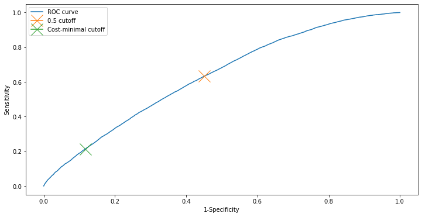

```python
# Plot ROC curve and mark cutoffs on the curve
plt.plot(fpr, tpr, label = "ROC curve")
plt.plot(fpr_default, tpr_default, marker="x", markersize=20, label ="0.5 cutoff")
plt.plot(fpr_bayes, tpr_bayes, marker="x", markersize=20,  label ="Cost-minimal cutoff")
plt.xlabel("1-Specificity")
plt.ylabel("Sensitivity")
plt.legend();
```

```
<sklearn.metrics._plot.confusion_matrix.ConfusionMatrixDisplay at 0x25a1b413550>
```

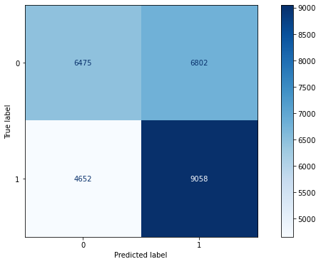

```python
from sklearn import metrics
metrics.plot_confusion_matrix(clf, X_test, y_test,  cmap=plt.cm.Blues, values_format='d') # Columns and rows have been transposed compared to above
```

Right upper corner is not small, not a very effective result.

```
<sklearn.metrics._plot.confusion_matrix.ConfusionMatrixDisplay at 0x25a1b5ae790>
```

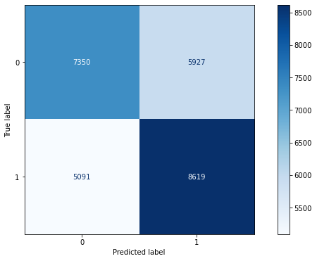

```python
metrics.plot_confusion_matrix(fit, X_test, y_test,  cmap=plt.cm.Blues, values_format='d') # Columns and rows have been transposed compared to above
```

With random forest, we see a slight improvement.

```python
# To calculate the error cost, we need to convert our predictions into the same format as the cost-matrix
cmat_default = metrics.confusion_matrix(y_test, pred_default)
cmat_bayes = metrics.confusion_matrix(y_test, pred_bayes)

# Calculate confusion matrix probabilities for each cell and multiply with cost-matrix to calculate the cost
print("The error cost for the default cutoff is: {}".format(np.sum(np.sum((cmat_default/len(y_test))*cost_matrix.T)))) # summarize to get total cost
print("The error cost for the cost-minimal cutoff is: {}".format(np.sum(np.sum((cmat_bayes/len(y_test))*cost_matrix.T))))
```

```
The error cost for the default cutoff is: 13.0500858993923
The error cost for the cost-minimal cutoff is: 12.517481710282729
```

```python
# Save function to calculate error-cost including option to adjust cutoff
def calc_error_cost(y_probabilities, y_test, cutoff, cost_matrix_df):
    pred = np.where(y_probabilities >= cutoff, 1, 0)                    # convert class probabilities into class predictions
    cmat = metrics.confusion_matrix(y_test, pred)                       # compute corresponding confusion matrix
    cost = (np.sum(np.sum((cmat/len(y_test))*cost_matrix.T))).round(5)  # calculate the corresponding cost
    return [cutoff, cost]
```

```python
# Save the results for the method comparison at the end

cutoff_cost_default = calc_error_cost(yhat, y_test, 0.5, cost_matrix)
cutoff_cost_bayes= calc_error_cost(yhat, y_test, threshold_bayes, cost_matrix)
cutoff_cost_bayes
```

```
[0.58736, 12.51748]
```

#### CV-method

```python
# To use cross-validation we refer back to this function we defined in the model assessment tutorial
from sklearn.utils import shuffle
def cv_split(seq, splits):
  return (seq[i::splits] for i in range(splits))

# Define function for threshold tuning
def lowest_error_cutoff(k, X_train_df, X_test_df, y_train_true, y_test_true, bayes_cost_matrix, y_test_probabilities):
  cutoffs_total = [] # save best cutoff from each split here, so we can average this cutoff later

  # Create a list of the index of our full data set as input, and k for the amount of splits
  cv_split_list = list(cv_split(shuffle(X_train_df.index.values.tolist(), random_state=888), k))

  for fold, i in enumerate(cv_split_list): # for each split

    temp = X_train_df.index.isin(i) # Create temp variable for data to exclude
    X_train_cv, y_train_cv = X_train_df.iloc[~temp], y_train_true[~temp] # Build model on all but hold out data
    X_test_cv, y_test_cv =  X_train_df.iloc[temp], y_train_true[temp] # Test on hold out data later
    rf.fit(X_train_cv, y_train_cv) # Train model
    pred_temp_prob = rf.predict_proba(X_test_cv)[:, 1] # Calculate class probabilities for current split

    # Define empty variable to save all cutoffs and corresponding errors. This way we can extract the lowest one for this split later
    cutoffs_cv = []
    error_cost_cv = []

    for j in  np.arange(0, 1, 0.001): # np.arrange(from, to, step-size)
              pred_temp = (pred_temp_prob >= j).astype(bool) # convert probabilities to class predictions
              cutoffs_cv.append(j) # save corresponding cutoff
              temp_cutoff_cost = calc_error_cost(pred_temp, y_test_cv, j, bayes_cost_matrix) # calculate cost and cutoff using our previously function
              error_cost_cv.append(temp_cutoff_cost[1]) # save error for the given cutoff

    temp_df = pd.DataFrame({"cutoffs":cutoffs_cv, "error_cost": error_cost_cv}).sort_values("error_cost")  # merge cutoffs and error cost, sort from lowest to highest by error_cost
    print("This is the fold number {}".format(fold+1)," of the cross-validation")
    print("The lowest error on the holdout data was achieved with the following cut-off: {}".format(temp_df.iloc[0].values[0]))
    print("The corresponding error cost is: {}".format(temp_df.iloc[0].values[1]))
    print("")
    cutoffs_total.append(temp_df.iloc[0, 0]) # save the lowest cutoff of this split to the list so we can average it at the end
    plt.plot(temp_df.cutoffs, temp_df.error_cost) # plot cutoffs and corresponding errors

  temp_cutoff_cost= calc_error_cost(y_test_probabilities, y_test_true, np.mean(cutoffs_total).round(5), bayes_cost_matrix) # np.mean(cutoffs_total) is the resulting best cutoff from the cross validation. We calculate the corresponding error-cost on the test data set
  plt.plot(temp_cutoff_cost[0], temp_cutoff_cost[1], marker='x', markersize=20, alpha=1, color='black', label="Average cutoff performance on test data") # plot cutoff and corresponding error on test set
  plt.title("Error Cost on Holdout Data by Threshold")
  plt.ylabel("Error Cost")
  plt.xlabel("Threshold")

  print("The best threshold according to cross-validated threshold tuning is: {}".format(temp_cutoff_cost[0]))
  print("On the test set, it has the following error cost: {}".format(temp_cutoff_cost[1]))
  return temp_cutoff_cost
```

```
This is the fold number 1  of the cross-validation
The lowest error on the holdout data was achieved with the following cut-off: 0.594
The corresponding error cost is: 11.75057
```

```
This is the fold number 2  of the cross-validation
The lowest error on the holdout data was achieved with the following cut-off: 0.596
The corresponding error cost is: 11.80373
```

```
This is the fold number 3  of the cross-validation
The lowest error on the holdout data was achieved with the following cut-off: 0.605
The corresponding error cost is: 11.79157
```

```
This is the fold number 4  of the cross-validation
The lowest error on the holdout data was achieved with the following cut-off: 0.5750000000000001
The corresponding error cost is: 12.04831
```

```
This is the fold number 5  of the cross-validation
The lowest error on the holdout data was achieved with the following cut-off: 0.5650000000000001
The corresponding error cost is: 11.59543

The best threshold according to cross-validated threshold tuning is: 0.587
On the test set, it has the following error cost: 12.52524
```

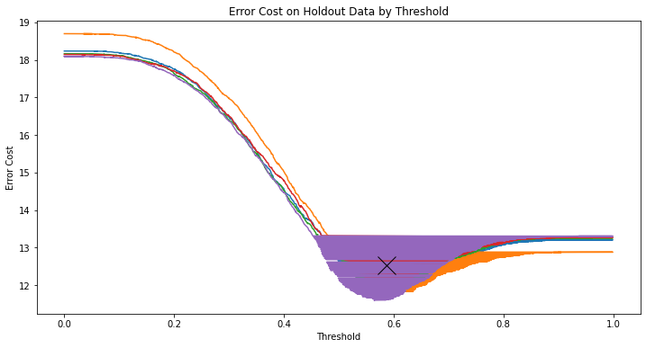

```python
# Calculate empirical threshold with 5 folds
cutoff_cost_cv = lowest_error_cutoff(5, X_train, X_test, y_train, y_test, cost_matrix, yhat)
```

```python
# Save confusion matrix for comparison later
cmat_CV = metrics.confusion_matrix(y_test, np.where(yhat >=  cutoff_cost_cv[0], 1, 0)) # compute corresponding confusion matrix

# Compare Bayes and CV-tuning and default

print("The error cost for the default cutoff is: {}".format(np.sum(np.sum((cmat_default/len(y_test))*cost_matrix.T)))) # summarize to get total cost
print("The cutoff and cost, respectively, for the Bayes model were: {}".format(cutoff_cost_bayes))
print("The cross-validated threshold tuning approach gave us the following cutoff and cost, respectively: {}".format(cutoff_cost_cv))
```

```
The error cost for the default cutoff is: 13.0500858993923
The cutoff and cost, respectively, for the Bayes model were: [0.58736, 12.51748]
The cross-validated threshold tuning approach gave us the following cutoff and cost, respectively: [0.587, 12.52524]
```

[figure not shown]

```python
# Calibration curve for LogitCV
from sklearn.calibration import calibration_curve

# Calculate calibration using calibration_curve function
prob_true, prob_pred= calibration_curve(y_test, yhat, n_bins = 20)

# Plot results
plt.plot(prob_pred, prob_true, marker = '.', label = 'Random Forest CV')
plt.title("Calibration Plot for Logit-CV model")
plt.ylabel("True Probability per Bin")
plt.xlabel("Predicted Probability")
plt.plot([0, 1], [0, 1], linestyle = '--', label = 'Ideally Calibrated');
plt.legend();
```

The calibration looks good.

```python
def MetaCost(X_train, X_test, y_train, relabel_model, final_model, optimal_cutoff):
  # Use model with good calibration to predict the new labels and create probability predictions
  temp_pred_proba_train = relabel_model.fit(X_train, y_train).predict_proba(X_train)[:,1]

  # Convert the probability predictions to class predictions using Bayes Decision Theory
  temp_pred_class_train = np.where(temp_pred_proba_train >= optimal_cutoff, 1, 0) # These are the new class labels

  # Fit a potent model to the test set, replacing our usual y_train with resulting class predictions from the last step
  final_model.fit(X_train, temp_pred_class_train)

  # Get predictions for the test set
  temp_pred_proba_test_cs = final_model.predict_proba(X_test)[:,1]

  return temp_pred_proba_test_cs
```

```python
from sklearn.linear_model import LogisticRegressionCV

# Apply function
pred_proba_MC = MetaCost(X_train, X_test, y_train, LogisticRegressionCV(), RandomForestClassifier(), threshold_bayes)

# Train model with original labels and predict the test set for comparison
pred_proba_RF = RandomForestClassifier().fit(X_train, y_train).predict_proba(X_test)[:,1];

# Save corresponding confusion matrix for evaluation
cmat_MC = metrics.confusion_matrix(y_test, np.where(pred_proba_MC >=  0.5, 1, 0))
```

```python
# Evaluate by calcuating the error-cost
cutoff_cost_MC = calc_error_cost(pred_proba_MC, y_test, 0.5, cost_matrix)
cutoff_cost_RF = calc_error_cost(pred_proba_RF, y_test, 0.5, cost_matrix)

print("The error-cost for the regular RF model is: {}".format(cutoff_cost_RF[1]))
print("The error-cost for the MetaCost approach is: {}".format(cutoff_cost_MC[1]))
```

```
The error-cost for the regular RF model is: 13.15244
The error-cost for the MetaCost approach is: 12.98091
```

```python
# Summarize all cutoffs and error-costs in one DataFrame
cutoff_cost_df = pd.DataFrame([cutoff_cost_default, cutoff_cost_bayes, cutoff_cost_cv, cutoff_cost_MC], columns=["Cutoff", "Error-Cost"], index=['Default', 'Bayes', 'Cross-Validation', 'MetaCost'])
cutoff_cost_df
```

|  | Cutoff | Error-Cost |
| --- | --- | --- |
| Default | 0.50000 | 13.05009 |
| Bayes | 0.58736 | 12.51748 |
| Cross-Validation | 0.58700 | 12.52524 |
| MetaCost | 0.50000 | 12.98091 |

Since Bayes treshhold provides the minimum cost that will be applied when classifying the probabilities.

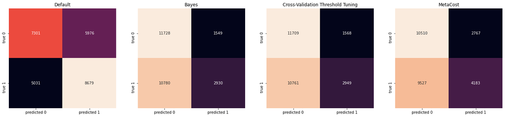

```python
# Plot Confusion Matrix using Heatmap
plt.rcParams['figure.figsize'] = (24, 5)

import seaborn as sns
fig, ax_lst = plt.subplots(1, 4)
cmat_list = [cmat_default, cmat_bayes, cmat_CV, cmat_MC]
csm_types = ["Default", "Bayes", "Cross-Validation Threshold Tuning", "MetaCost"] # types of cost-sensitive methods

for i, j, ax in zip(cmat_list, csm_types, ax_lst.flat):

    # Plot heatmap
    ax.set_title(j)
    sns.heatmap(i, ax=ax, annot=True, fmt='g', cbar=False, xticklabels=['predicted 0', 'predicted 1'], yticklabels=['true 0', 'true 1'])

plt.show()
```

In order to minimize the total cost, (compared to the default cut-off) cost minimization algorithms chose to let the cases where we predict the item won't be returned but it is in reality returned increase so that the cases where we predict an item to be returned but it is kept are minimized.

```python
# Select random state to make results reproducable for sklearn functions
import random
rnd_state = 888
random.seed(a=rnd_state)

import warnings
```

```python
# Logistic Regression CV
clf = LogisticRegressionCV(cv=5, random_state=rnd_state, fit_intercept=True).fit(X_train, np.ravel(y_train))
y_pred_logcv_uw = clf.predict(X_test)
y_pred_proba_logcv_uw = clf.predict_proba(X_test)[:,1]
```

```python
# LogitCV Weighted vs. unweighted
acc = metrics.accuracy_score(y_test, y_pred_logcv_uw)
fpr, tpr, thresholds = metrics.roc_curve(y_test, y_pred_logcv_uw, pos_label=1)
auc = metrics.auc(fpr, tpr)

print("The unweighted LogitCV model predicted the minority class {:.2f}".format(y_pred.sum()/len(y_pred)*100),"% of the time")
print("The AUC is {:.2f}".format(auc))
print("The sensitivity for the model is {:.2f}".format(tpr[1]))
print("")

# Fit a model with the regular data with balanced weights

clf = LogisticRegressionCV(cv=5, random_state=rnd_state, fit_intercept=True, class_weight='balanced').fit(X_train, np.ravel(y_train))
y_pred_cv_w = clf.predict(X_test)
y_pred_proba_tree_w = clf.predict_proba(X_test)[:,1]
cutoff_cost_default = calc_error_cost(y_pred_proba_tree_w, y_test, 0.5, cost_matrix)

acc = metrics.accuracy_score(y_test, y_pred)
fpr, tpr, thresholds = metrics.roc_curve(y_test, y_pred, pos_label=1)
auc = metrics.auc(fpr, tpr)

print("The weighted LogitCV model predicted the minority class {:.2f}".format(y_pred.sum()/len(y_pred)*100),"% of the time")
print("The AUC is {:.2f}".format(auc))
print("The sensitivity for the model is {:.2f}".format(tpr[1]))
```

```
The unweighted LogitCV model predicted the minority class 58.77 % of the time
The AUC is 0.57
The sensitivity for the model is 0.66

The weighted LogitCV model predicted the minority class 58.77 % of the time
The AUC is 0.57
The sensitivity for the model is 0.66
```

```python
# Define weights
weights = {0:1, 37.0311686:26.0155843}
```

```python
# Error cost for weighted vs. unweighted LogitCV model
print('The error cost of the unweighted LogitCV model is: {}'.format(calc_error_cost(y_pred_proba_logcv_uw, y_test, 0.5, cost_matrix)[1]))

# Train model and get probabilities
y_pred_proba = LogisticRegressionCV(cv=5, random_state=rnd_state, fit_intercept=True, class_weight=weights).fit(X_train, np.ravel(y_train)).predict_proba(X_test)[:,1]
print('The error cost of the weighted LogitCV model is: {}'.format(calc_error_cost(y_pred_proba, y_test, 0.5, cost_matrix)[1]))
```

```
The error cost of the unweighted LogitCV model is: 13.79935
```

[output not shown]